# 03_Assignment

Igor Moloko, Jiujiu Liao

2025-07-04

Topic Introduction: This study examines the spatial relationship between forest cover changes and air quality improvements in Germany between April 2017 and April 2023. Using forest cover data from the German Aerospace Center (DLR) and air quality reanalysis data from the Copernicus Atmosphere Monitoring Service (CAMS), we analyzed the correlation between changes in forest coverage and concentrations of nitrogen dioxide (NO₂) and fine particulate matter (PM₂.₅). Contrary to expectations, our analysis revealed weak positive correlations between forest cover increase and pollutant concentrations (r = 0.22 for NO₂, r = 0.26 for PM₂.₅, both p < 0.001). These counterintuitive findings suggest that confounding factors such as regional development patterns and urbanization may overshadow the local air quality benefits of forests at the spatial scale examined. The results highlight the complexity of environmental interactions and the importance of considering multiple variables when assessing ecosystem services.

# Download the map of Germany

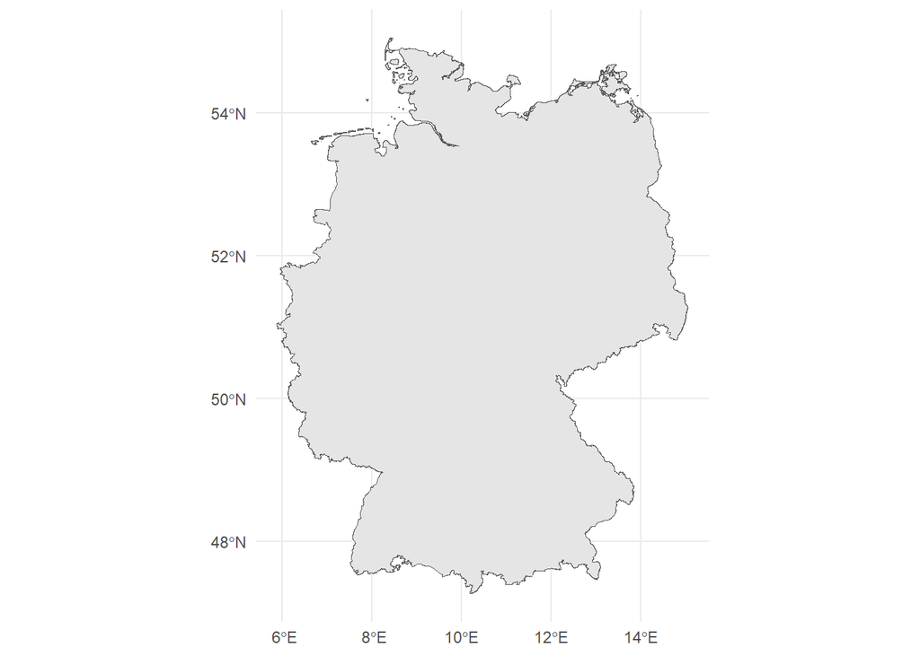

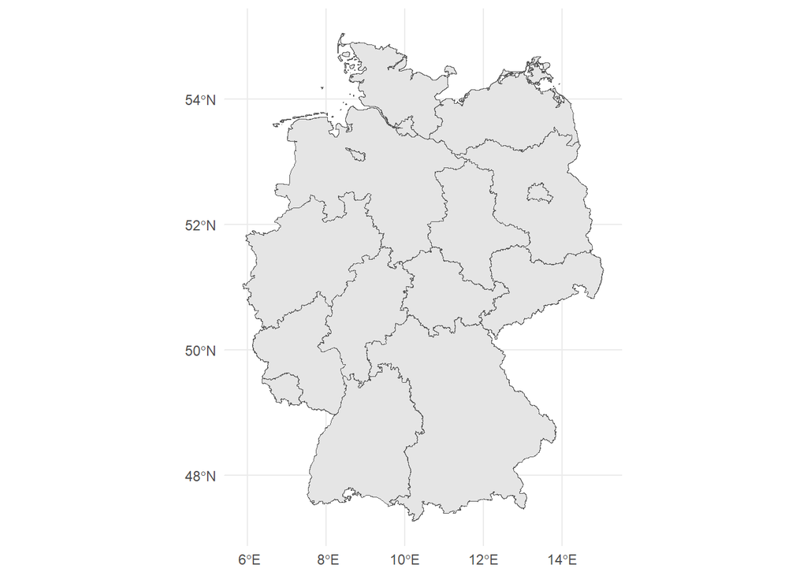

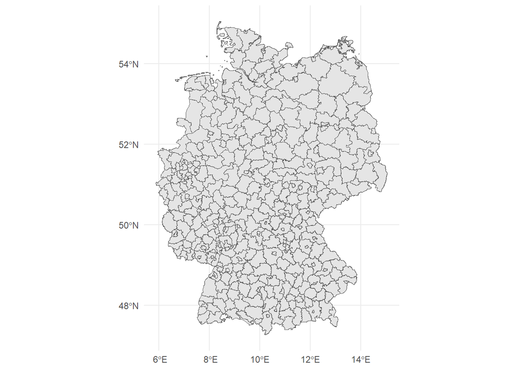

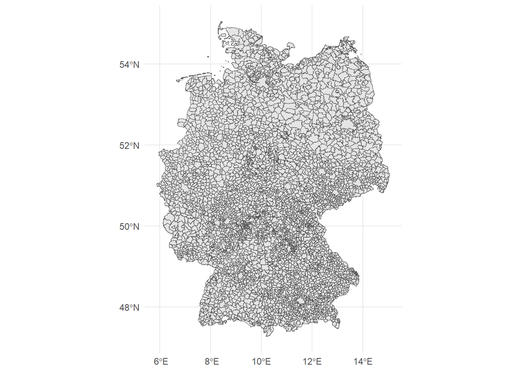

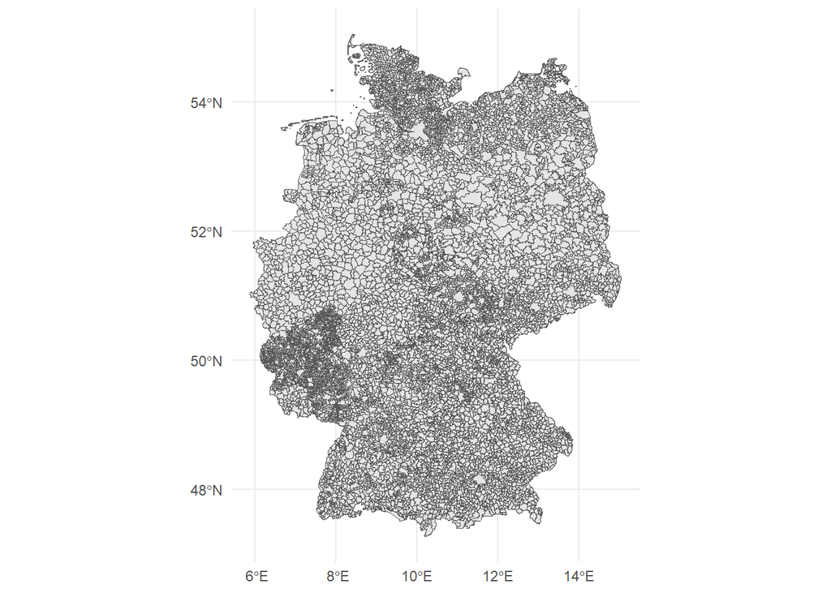

# Download maps of forests in Germany for 2017 and 2023

```
## Response [https://download.geoservice.dlr.de/FSG/files/2017/2017_cover_overview.tif]
##   Date: 2025-07-07 01:48
##   Status: 200
##   Content-Type: image/tiff
##   Size: 2.94 MB
## <ON DISK>  C:\Users\jiuji\OneDrive\Desktop\Fourth Semester\03_Assignment_Jiujiu\data\raw\forest_cover\2017_cover_overview.tif
```

```
## Response [https://download.geoservice.dlr.de/FSG/files/2023/2023_cover_overview.tif]
##   Date: 2025-07-07 01:48
##   Status: 200
##   Content-Type: image/tiff
##   Size: 3.16 MB
## <ON DISK>  C:\Users\jiuji\OneDrive\Desktop\Fourth Semester\03_Assignment_Jiujiu\data\raw\forest_cover\2023_cover_overview.tif
```

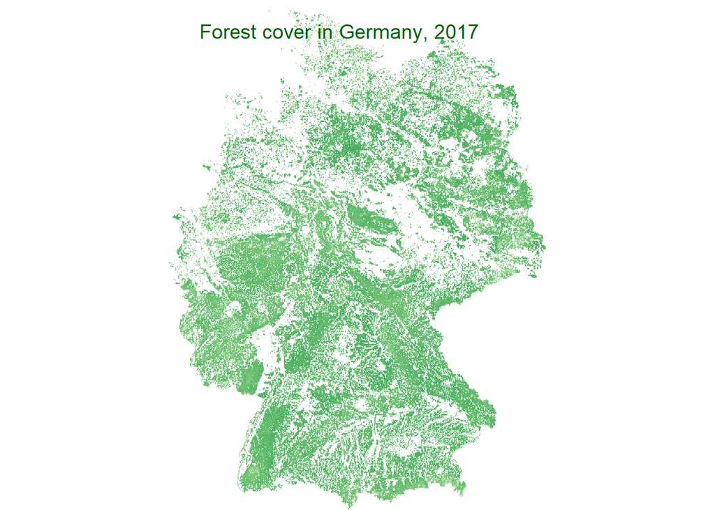

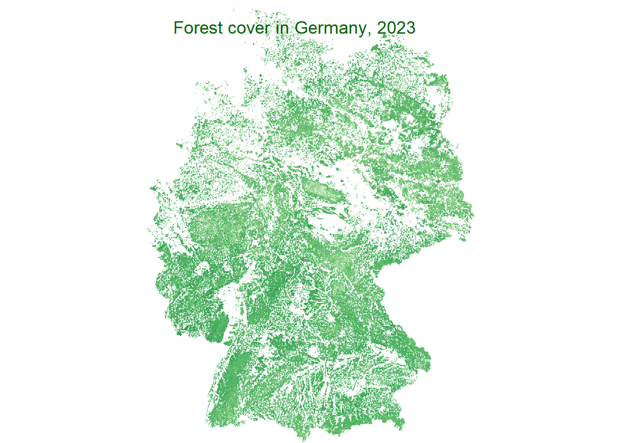

Visually, the maps show that the forest area in Germany has increased over the past 6 years, but to confirm this, we need to calculate the numerical values.

An excel table was created based on data from the website https://www.bundeswaldinventur.de/

```
## Forest area in Germany in 2017:  11,410,372 ha
```

```
## Forest area in Germany in 2023:  11,538,455 ha
```

```
## Change in forest area:  128,083 ha
```

Results indicates a modest overall increase in forest area over the six-year period, suggesting that reforestation and afforestation efforts have slightly outpaced deforestation and land-use changes.

Let’s build a map of Saxony’s forests for a similar period of time

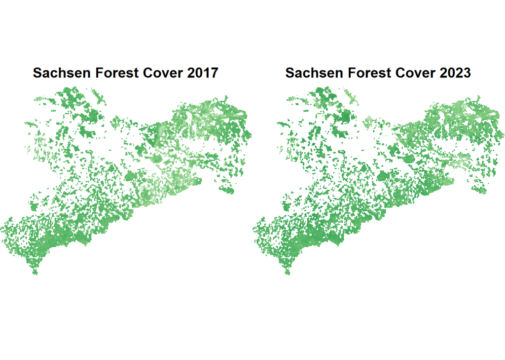

Looking at the map of forest cover in Saxony, one can also notice their increase, but to prove it, we will calculate a specific value

We calculate data for Saxony

```
## Forest area in Saxony in 2017:  524,960 ha
```

```
## Forest area in Saxony in 2023:  531,219 ha
```

```
## Change in forest area (Saxony):  6,259 ha
```

This reflects a small but positive increase in the forest area in Saxony over the six-year period, indicating ongoing efforts toward forest conservation and expansion in the region.

Let’s check the forest cover data of Dresden

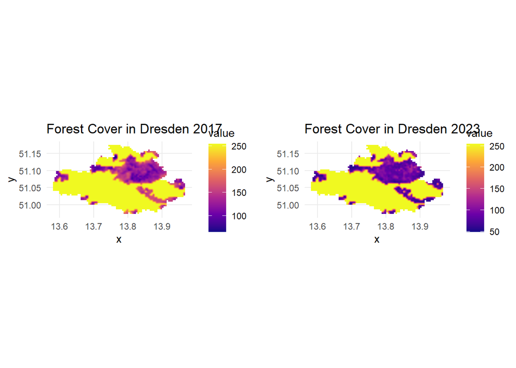

The map of Dresden at first glance looks as if the forest cover has decreased. Unfortunately, we did not find any digital data, so it is difficult to prove

#############Part 2 Air Quality Data#############

because the CDS database only provide access for python, so here we used python chunk.

2 prerequisites: 1.please download python 2.please create a file called ‘.cdsapirc’ under the path of User/$home 3.paste this two lines of code in this ‘.cdsapirc’ file url: https://ads.atmosphere.copernicus.eu/api key: 957eaa7d-2d43-4f56-893a-ec7c34875c99

more instruction for windows please check this website:https://confluence.ecmwf.int/display/CKB/How+to+install+and+use+CDS+API+on+Windows

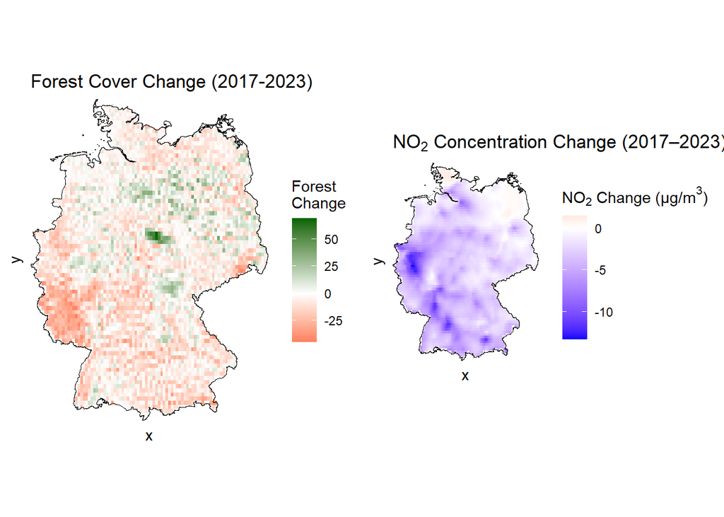

This image displays two maps illustrating the distribution of Nitrogen Dioxide concentrations across Germany for the years 2017 and 2023.

In 2017, higher concentrations of NO₂, reaching up to 30 µg/m³, are visible in several urban and industrial areas, particularly in western and southern Germany.

By 2023, there is a noticeable overall decrease in NO₂ levels across the country. The color scale for 2023 indicates a lower maximum concentration, around 20 µg/m³. While some urban regions still show relatively higher concentrations compared to rural areas, the peak levels are visibly lower than in 2017, and the spatial extent of these higher concentration zones appears to have diminished.

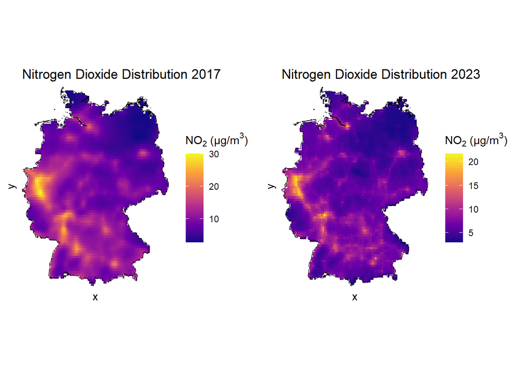

This series of maps illustrates the changes in mean Nitrogen Dioxide concentrations across German states between 2017 and 2023.

The first two maps show the NO₂ distribution in 2017 and 2023, respectively, using the same “pretty” interval classification. In 2017, higher concentrations (ranging from 10 to 18 µg/m³) were concentrated in western and southern states, as well as the city-states of Berlin and Hamburg. By 2023, a clear nationwide reduction is visible, with the highest concentrations dropping to a range of 8 to 12 µg/m³.

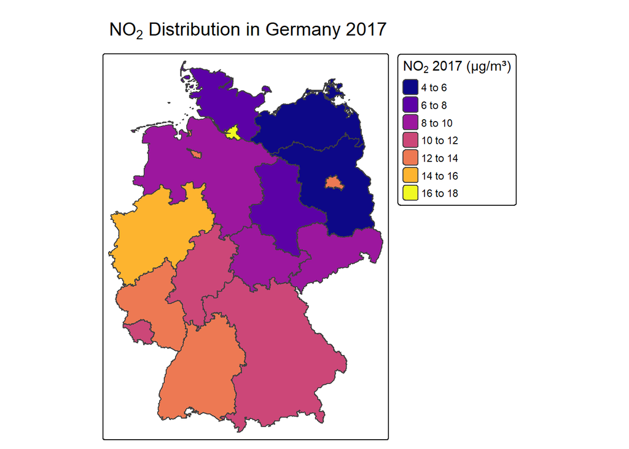

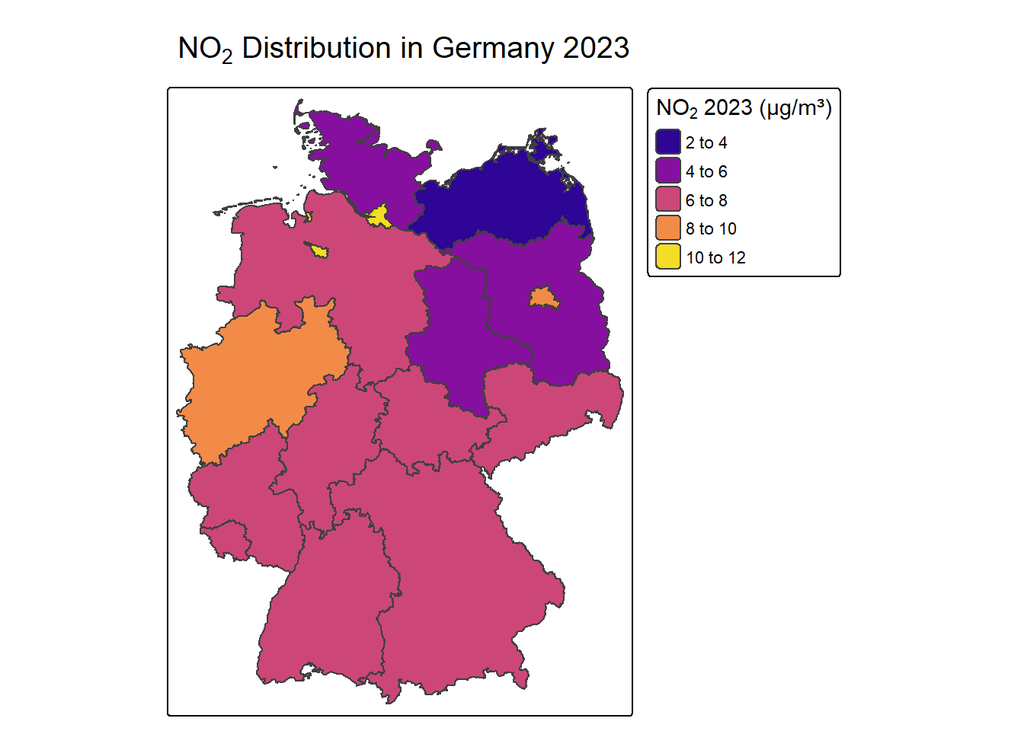

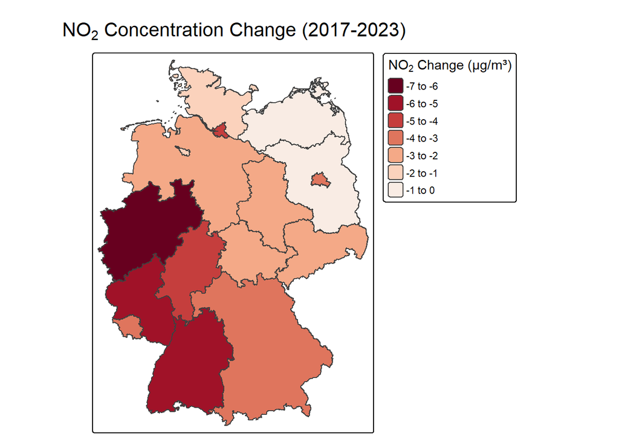

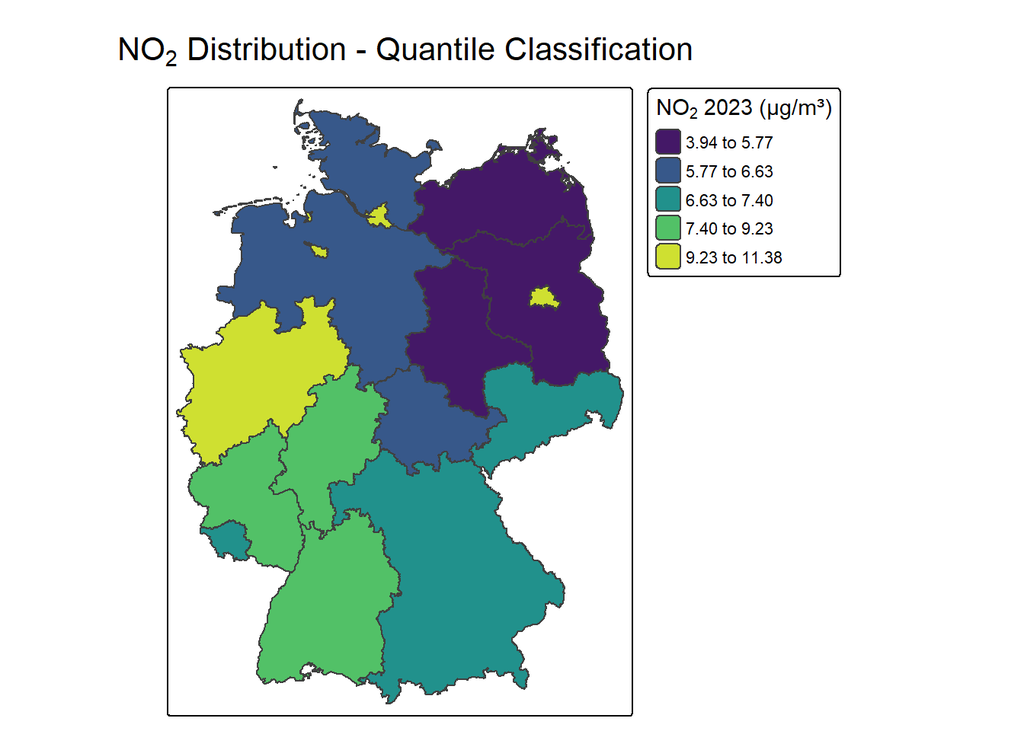

```
## [1] 78 92  3
```

```
## [1] 78 92  1
```

```
## class       : SpatRaster
## dimensions  : 78, 92, 1  (nrow, ncol, nlyr)
## resolution  : 0.09985735, 0.09975062  (x, y)
## extent      : 5.85592, 15.0428, 47.25686, 55.03741  (xmin, xmax, ymin, ymax)
## coord. ref. : lon/lat WGS 84 (EPSG:4326)
## source(s)   : memory
## name        : 2023_cover_overview_1
## min value   :             -44.60631
## max value   :              68.89802
```

```
## class       : SpatRaster
## dimensions  : 78, 92, 1  (nrow, ncol, nlyr)
## resolution  : 0.09985735, 0.09975062  (x, y)
## extent      : 5.85592, 15.0428, 47.25686, 55.03741  (xmin, xmax, ymin, ymax)
## coord. ref. : lon/lat WGS 84 (EPSG:4326)
## source(s)   : memory
## name        : 2023_cover_overview_2
## min value   :              -23.0912
## max value   :               30.9348
```

```
## class       : SpatRaster
## dimensions  : 78, 92, 1  (nrow, ncol, nlyr)
## resolution  : 0.09985735, 0.09975062  (x, y)
## extent      : 5.85592, 15.0428, 47.25686, 55.03741  (xmin, xmax, ymin, ymax)
## coord. ref. : lon/lat WGS 84 (EPSG:4326)
## source(s)   : memory
## name        : 2023_cover_overview_3
## min value   :             -33.16267
## max value   :              55.81332
```

```
## === DESCRIPTIVE STATISTICS ===
```

```
## Forest Cover Change:
```

```
## Mean: -5.31
```

```
## SD: 12.8821
```

```
## Min: -44.6063
```

```
## Max: 68.898
```

```
## Median: -5.2889
```

```
##
## NO2 Concentration Change:
```

```
## Mean: -3.2306
```

```
## SD: 2.2979
```

```
## Min: -13.2878
```

```
## Max: 1.4824
```

```
## Median: -3.0326
```

```
##
## === CORRELATION ANALYSIS ===
```

```
## Pearson Correlation Coefficient: 0.2206
```

```
## P-value: 2.062156e-50
```

```
## 95% Confidence Interval: 0.1926 to 0.2483
```

The scatter plot and the positive correlation coefficient show a counterintuitive trend: areas with greater forest gain (or less forest loss, moving right on the x-axis) are associated with a smaller decrease in NO₂ pollution (a less negative, or higher, value on the y-axis).

It is crucial not to interpret this as causation (i.e., that adding forests worsens air pollution).

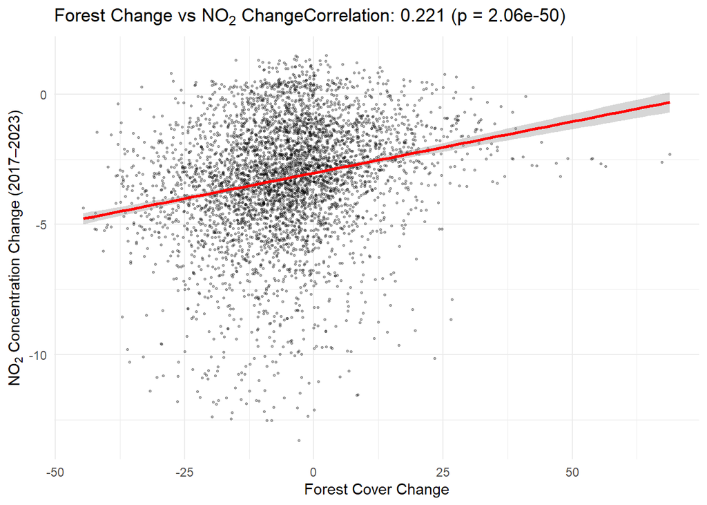

This map classifies the relationship between forest cover change and NO₂ air quality change across Germany, revealing distinct regional patterns. Each pixel is colored based on whether its changes were better or worse than the national median.

Green - “Positive Impact”: Concentrated in central Germany, these areas represent the ideal scenario where an increase in forest cover occurred alongside a strong decrease in NO₂ pollution.

Challenging Areas (Red & Orange): The red areas (“Negative Impact”), mainly in the northeast, are regions of concern where forest cover was lost while air quality improvements lagged. The orange areas (“Unexpected 1”) show that even with gains in forest cover, these regions failed to see a corresponding significant improvement in air quality, pointing to other persistent local pollution sources.

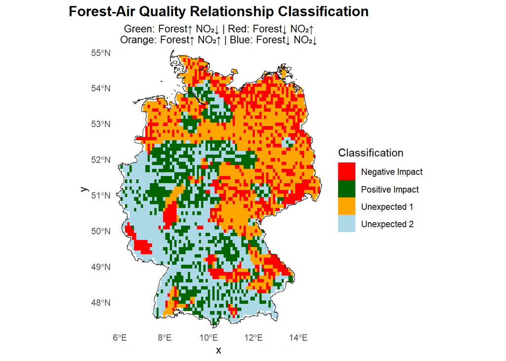

```
##
## === SPATIAL OVERLAY ANALYSIS ===
```

```
## Area distribution by category:
```

```
## Negative Impact : 19.82 %
## Positive Impact : 19.82 %
## Unexpected 1 : 30.18 %
## Unexpected 2 : 30.18 %
```

```
##                   Variable    Mean      SD      Min     Max  Median
## 1      Forest Cover Change -5.3100 12.8821 -44.6063 68.8980 -5.2889
## 2 NO₂ Concentration Change -3.2306  2.2979 -13.2878  1.4824 -3.0326
```

```
##
## === ANALYSIS COMPLETE ===
```

```
## Key Findings:
```

```
## 1. Correlation coefficient: 0.221
```

```
## 2. Statistical significance: p = 2.062156e-50
```

A significant overall reduction in PM2.5 levels is evident between the two years. The color scale indicates that the peak concentrations decreased from approximately 15.0 µg/m³ in 2017 to around 10.0 µg/m³ in 2023.

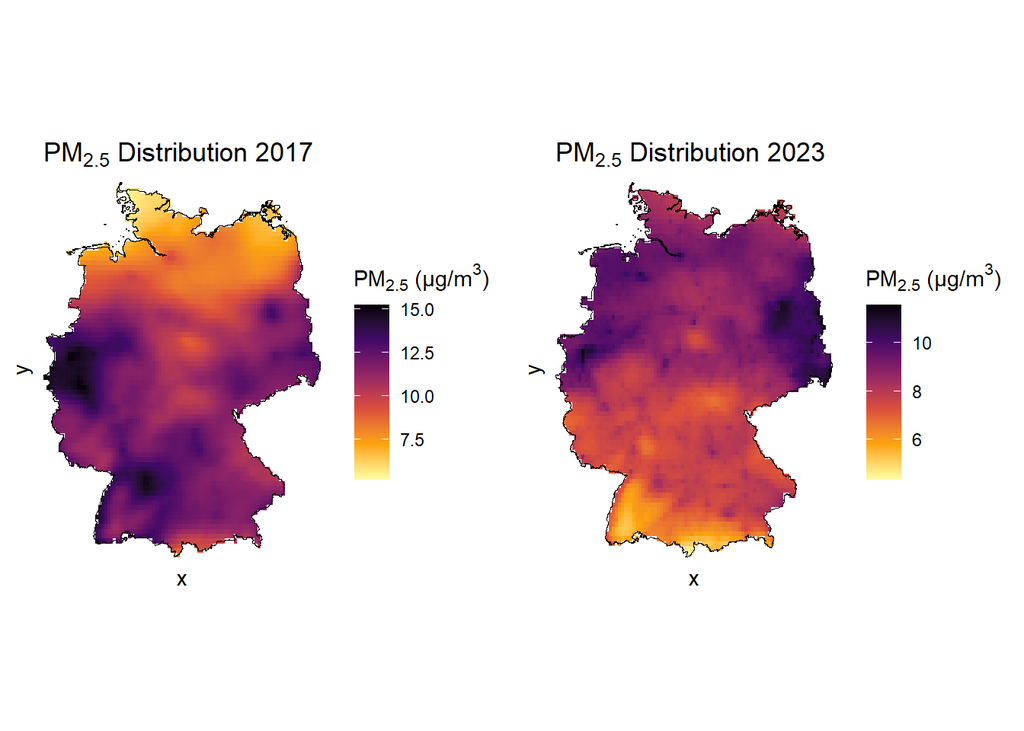

The map on the left, “Forest Cover Change,” shows significant regional variations. Widespread forest loss (indicated in orange/red) is evident across southern and western Germany. In contrast, areas of forest gain (green) are visible in parts of the north and east.

The map on the right, “PM₂.₅ Concentration Change,” reveals a clear and widespread decrease in fine particulate matter across the country, indicated by the predominantly blue coloration. The most substantial reductions in PM2.5(darkest blue) occurred in western and southern Germany.

Notably, the regions experiencing the most significant forest loss (west and south) are also the areas that saw the largest improvements in air quality. This suggests that the reduction in PM 2.5 was primarily driven by factors other than the change in forest cover.

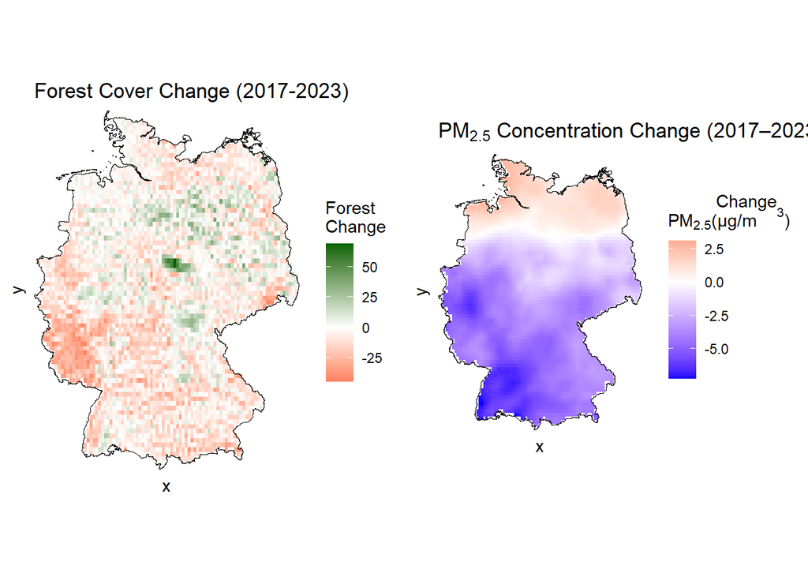

This set of maps illustrates the distribution and change in average PM2.5 concentrations across German states between 2017 and 2023.

By 2023, this pattern had completely inverted. The southern states, particularly Baden-Württemberg and Bavaria, now show the lowest concentrations in the country. The relatively higher levels of PM2.5 are now found in the northern and eastern states.

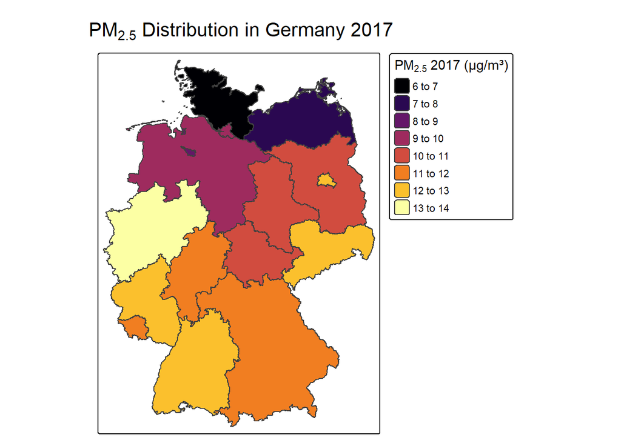

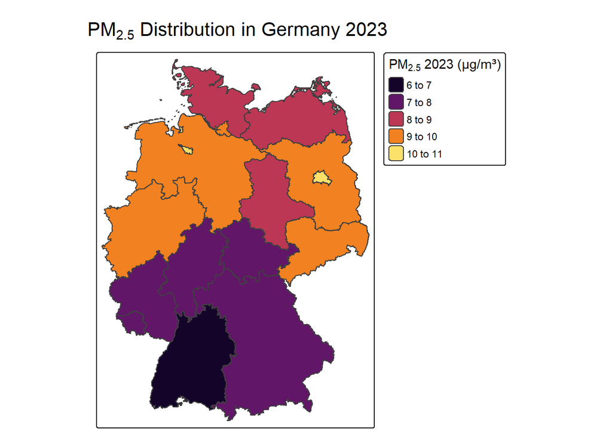

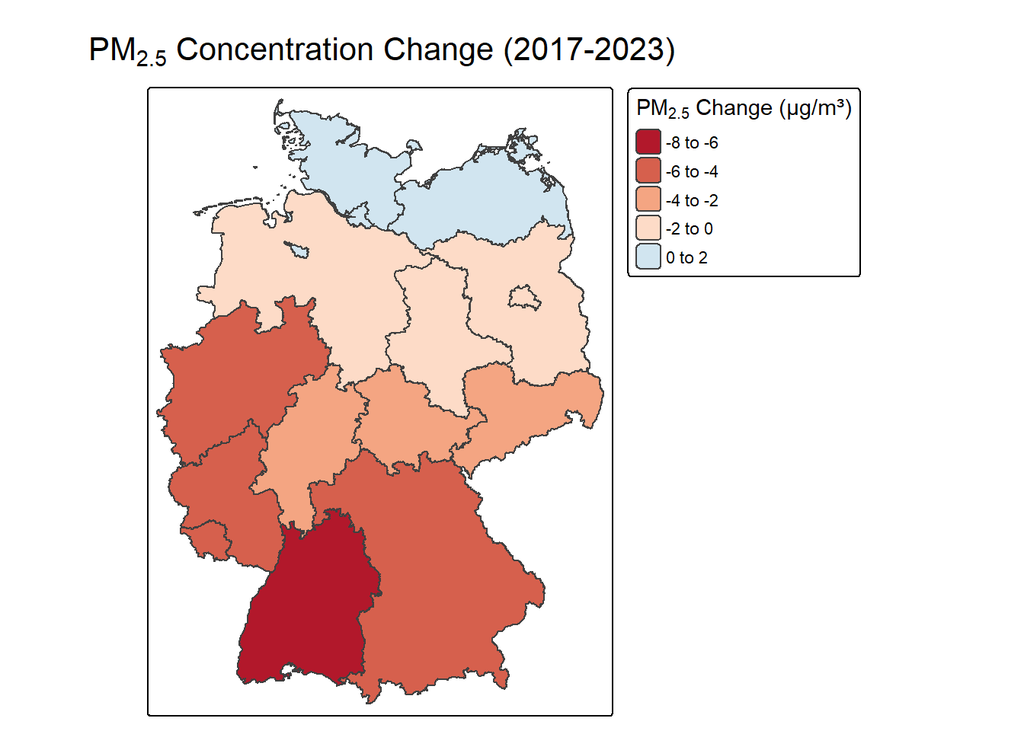

This scatter plot illustrates the relationship between changes in forest cover and changes in PM2.5 concentration at a granular level across Germany from 2017 to 2023.

The analysis finds a weak but highly statistically significant positive correlation (r = 0.256, p < 0.001). The upward-sloping red trend line indicates that areas with greater forest gain (or less forest loss) are unexpectedly associated with smaller reductions in PM2.5 pollution.

```
## === PM2.5 DESCRIPTIVE STATISTICS ===
```

```
## PM2.5 Concentration Change:
```

```
## Mean: -2.5283
```

```
## SD: 2.4119
```

```
## Min: -7.249
```

```
## Max: 3.0866
```

```
## Median: -3.1414
```

```
##
## === FOREST vs PM2.5 CORRELATION ANALYSIS ===
```

```
## Pearson Correlation Coefficient: 0.2557
```

```
## P-value: 1.160349e-67
```

```
## 95% Confidence Interval: 0.2281 to 0.2829
```

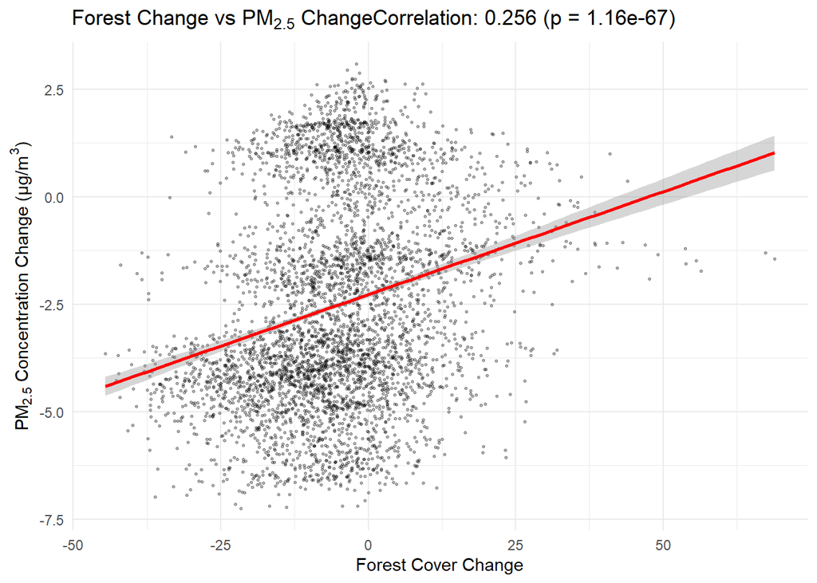

This map classifies Germany into four distinct zones by comparing local changes in forest cover and PM2.5 against their respective national medians.

The map reveals a stark north-south divide. Southern Germany (Predominantly Light Blue & Green): This region is dominated by the “Unexpected 2” category, where significant reductions in PM2.5 occurred despite forest loss. This strongly indicates that factors other than forestry, such as industrial and policy changes, were the main drivers of improved air quality here. Pockets of “Positive Impact” (green) show where both indicators improved favorably.

Northern Germany (Predominantly Red & Orange): This region is characterized by lagging air quality performance. Areas saw either a combination of forest loss and poor air quality outcomes (red) or forest gain that was not met with significant pollution reduction (orange).

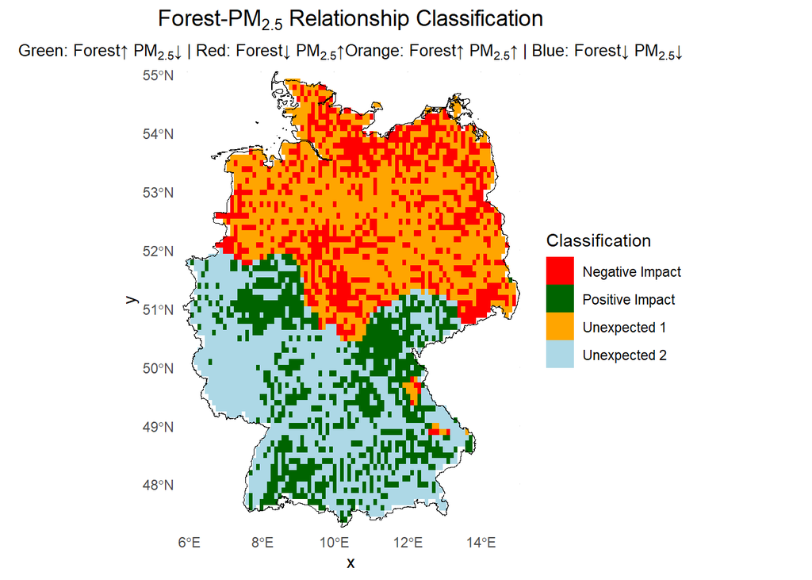

```
##
## === PM2.5 SPATIAL OVERLAY ANALYSIS ===
```

```
## Area distribution by category:
```

```
## Negative Impact : 18.9 %
## Positive Impact : 18.9 %
## Unexpected 1 : 31.1 %
## Unexpected 2 : 31.1 %
```

```
##
## === COMPARATIVE ANALYSIS ===
```

```
## Forest vs NO₂ correlation: 0.221
```

```
## Forest vs PM2.5 correlation: 0.256
```

```
## Difference in correlation strength: 0.035
```

```
## P-value for correlation difference: 7.889746e-02
```

```
##   Pollutant Correlation      P_value CI_Lower CI_Upper
## 1       NO₂      0.2206 2.062156e-50   0.1926   0.2483
## 2     PM2.5      0.2557 1.160349e-67   0.2281   0.2829
```

```
##
## === ANALYSIS COMPLETE ===
```

```
## Key Findings for PM2.5:
```

```
## 1. Correlation coefficient: 0.256
```

```
## 2. Statistical significance: p = 1.160349e-67
```

```
## 3. Comparison with NO₂: PM2.5 shows stronger correlation with forest change
```

# FINAL RESULTS INTERPRETATION

SUMMARY OF FINDINGS: This analysis examined the association between forest cover change and air quality change (NO2 and PM2.5) in Germany between April 2017 and April 2023.

# KEY FINDINGS:

1. FOREST-NO2 RELATIONSHIP:

[output not shown]

2. FOREST-PM2.5 RELATIONSHIP:

[output not shown]

3. PM2.5 TRENDS:

```
- Mean change: -2.53 μg/m³ (overall reduction in PM2.5 level)

- Median: -3.14 μg/m³ (most places had PM2.5 reduction)

- Range: -7.25 to 3.09 μg/m³ (varied spatial patterns)
```

# CONCLUSION:

While statistically significant, the low correlation values (0.22-0.26) indicate that changes in forest cover explain only 5-7% of variation in changes in air quality. Positive correlations highlight the richness of environmental association and demand the assessment of many confounding factors in environmental effect assessments.